# Human Activity Recognition

Venkadeshwaran K

May 20, 2016

## Data Loading

The data is taken from the source [LES Groupware](http://groupware.les.inf.puc-rio.br/har). Lets us grab the data from the cloud.

```r
trainurl <- 'https://d396qusza40orc.cloudfront.net/predmachlearn/pml-training.csv'
testurl <- 'https://d396qusza40orc.cloudfront.net/predmachlearn/pml-testing.csv'

training <- read.csv(trainurl, na.strings = c('NA', "#DIV/0!", ""))
testing <- read.csv(testurl, na.strings = c('NA', "#DIV/0!", ""))

c(dim(training), dim(testing))
```

```
## [1] 19622   160    20   160
```

The training data has 19622 rows and the testing dataset has 20 records. Both the data set has 160 columns.

## Data Processing

### Filtering Columns

Doing Exploratory data analysis on this data set with more columns will be very difficult. So let us do some prepreprocessing first. The NA data can not be processed in ML programs. So we can remove the columns with null values.

```r
library(caret)

training <- training[, colSums(is.na(training))==0 ]
testing <- testing[, colSums(is.na(testing)) == 0]


## Extracting Classe field
classe <- training$classe
## Removing unwanted problem id column from testing data

training <- training[, -c(1:7, 60) ] ## 60 - classe
testing <- testing[, -c(1:7, 60)] ## 60 - problem_id

c(dim(training), dim(testing))
```

```
## [1] 19622    52    20    52
```

### Data Spliting

We can split the train data into training data and Validate data with the .7 proportion. And we can proceed with the preProcessing

```r
set.seed(2708)
inTrain <- createDataPartition(classe, p = 0.7, list = FALSE)

train <- training[inTrain,]
valid <- training[-inTrain,]

## Saving the classe in separate vector
train_classe <- classe[inTrain]
valid_classe <- classe[-inTrain]
```

### PreProcessing

We can preprocess the record with None-Zero Variance factor. This will help us to restrict the fields which are not much important to the prediction.

```r
prepro <- preProcess(train, method = c('center','scale','nzv'))
prepro
```

[output not shown]

We will apply the preprocess directly in the train method

## Prediction Modeling

Since the Output is the factor varaible we can go with classification method. As the part of this experiment we will be using Tree and Random Forest.

### Classification Tree Model

In practice, k=5 or k=10 when doing k-fold cross validation. Here we consider 5-fold cross validation (default setting in trainControl function is 10 and default method=‘boost’) when implementing the algorithm to save a little computing time. Since data transformations may be less important in non-linear models like classification trees, we do not transform any variables.

```r
library(rpart)
library(rattle)
library(rpart.plot)
ctrl <- trainControl(method = "cv", number = 5)
fit_rpart <- train(train_classe ~ ., data = train, method = "rpart",
                   trControl = ctrl, preProcess=c('center','scale','nzv'))
print(fit_rpart, digits = 4)
```

```
## CART
##
## 13737 samples
##    51 predictor
##     5 classes: 'A', 'B', 'C', 'D', 'E'
##
## Pre-processing: centered (52), scaled (52)
## Resampling: Cross-Validated (5 fold)
## Summary of sample sizes: 10991, 10990, 10987, 10990, 10990
## Resampling results across tuning parameters:
##
##   cp       Accuracy  Kappa
##   0.03611  0.5048    0.35282
##   0.05917  0.4397    0.24911
##   0.11494  0.3166    0.04939
##
## Accuracy was used to select the optimal model using  the largest value.
## The final value used for the model was cp = 0.03611.
```

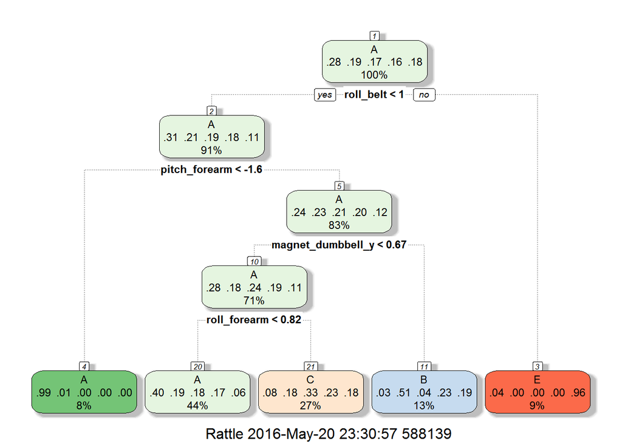

```r
fancyRpartPlot(fit_rpart$finalModel)
```

```r
# predict and Validate outcomes using validation set
predict_rpart <- predict(fit_rpart, valid)
# ConfusionMatrix to find the accuracy
conf_rpart <- confusionMatrix(valid_classe, predict_rpart)
conf_rpart
```

```
## Confusion Matrix and Statistics
##
##           Reference
## Prediction    A    B    C    D    E
##          A 1516   30   99    0   29
##          B  458  409  272    0    0
##          C  472   44  510    0    0
##          D  418  180  366    0    0
##          E  130  145  283    0  524
##
## Overall Statistics
##
##                Accuracy : 0.5028
##                  95% CI : (0.4899, 0.5157)
##     No Information Rate : 0.5088
##     P-Value [Acc > NIR] : 0.8227
##
##                   Kappa : 0.351
##  Mcnemar's Test P-Value : NA
##
## Statistics by Class:
##
##                      Class: A Class: B Class: C Class: D Class: E
## Sensitivity            0.5063   0.5062  0.33333       NA  0.94756
## Specificity            0.9453   0.8562  0.88152   0.8362  0.89535
## Pos Pred Value         0.9056   0.3591  0.49708       NA  0.48429
## Neg Pred Value         0.6490   0.9159  0.79008       NA  0.99396
## Prevalence             0.5088   0.1373  0.25998   0.0000  0.09397
## Detection Rate         0.2576   0.0695  0.08666   0.0000  0.08904
## Detection Prevalence   0.2845   0.1935  0.17434   0.1638  0.18386
## Balanced Accuracy      0.7258   0.6812  0.60742       NA  0.92145
```

```r
accuracy_rpart <- conf_rpart$Overall[1]
```

The resultant outcome is very less. Lets hope the random forest will give better result.

### RandomForest Model Building

Random Forest will be more accurate to most of the datasets. If this also doesnt predict with accuracy then we shall go with the Combining model Prediction.

```r
fit_rf <- train(train_classe ~ ., data = train, method = "rf",
                   trControl = ctrl, preProcess=c('center','scale','nzv'))
print(fit_rf, digits = 4)
```

```
## Random Forest
##
## 13737 samples
##    51 predictor
##     5 classes: 'A', 'B', 'C', 'D', 'E'
##
## Pre-processing: centered (52), scaled (52)
## Resampling: Cross-Validated (5 fold)
## Summary of sample sizes: 10991, 10989, 10989, 10989, 10990
## Resampling results across tuning parameters:
##
##   mtry  Accuracy  Kappa
##    2    0.9908    0.9884
##   27    0.9908    0.9884
##   52    0.9849    0.9808
##
## Accuracy was used to select the optimal model using  the largest value.
## The final value used for the model was mtry = 27.
```

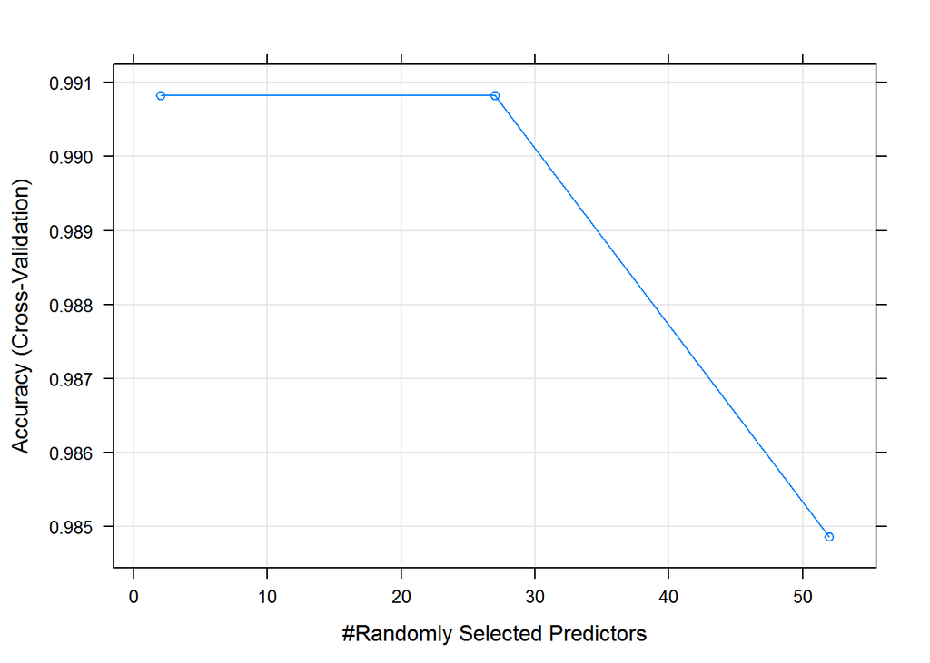

```r
plot(fit_rf)
```

```r
# predict and Validate outcomes using validation set
predict_rf <- predict(fit_rf, valid)
# ConfusionMatrix to find the accuracy
conf_rf <- confusionMatrix(valid_classe, predict_rf)
conf_rf
```

```
## Confusion Matrix and Statistics
##
##           Reference
## Prediction    A    B    C    D    E
##          A 1667    4    3    0    0
##          B    9 1128    2    0    0
##          C    0    3 1019    4    0
##          D    0    0    7  956    1
##          E    0    0    1    1 1080
##
## Overall Statistics
##
##                Accuracy : 0.9941
##                  95% CI : (0.9917, 0.9959)
##     No Information Rate : 0.2848
##     P-Value [Acc > NIR] : < 2.2e-16
##
##                   Kappa : 0.9925
##  Mcnemar's Test P-Value : NA
##
## Statistics by Class:
##
##                      Class: A Class: B Class: C Class: D Class: E
## Sensitivity            0.9946   0.9938   0.9874   0.9948   0.9991
## Specificity            0.9983   0.9977   0.9986   0.9984   0.9996
## Pos Pred Value         0.9958   0.9903   0.9932   0.9917   0.9982
## Neg Pred Value         0.9979   0.9985   0.9973   0.9990   0.9998
## Prevalence             0.2848   0.1929   0.1754   0.1633   0.1837
## Detection Rate         0.2833   0.1917   0.1732   0.1624   0.1835
## Detection Prevalence   0.2845   0.1935   0.1743   0.1638   0.1839
## Balanced Accuracy      0.9965   0.9958   0.9930   0.9966   0.9993
```

```r
accuracy_rf <- conf_rf$overall[1]
accuracy_rf
```

```
##  Accuracy
## 0.9940527
```

The accuracy is 99% which is very high. But the random forest with take more computational time.

**Sample Error** 1 - .994 which is less than 1%.

## Outcome Predicition on Test Data

So on predicting the Validation dataset we find the randomforest model is very accurate. Lets apply the same on the test data.

```r
predict(fit_rf, testing)
```

```
##  [1] B A B A A E D B A A B C B A E E A B B B
## Levels: A B C D E
```

The above is the classe of the test data.